[figure not shown]

# Aula 5 - Operações Long & Short

A presente atividade abordará operações Long & Short baseadas no spread entre pares de ações, sendo a "aposta" a diminuição do spread a partir de um determinado ponto de distorção. Diversas medidas quantitativas são possíveis na avaliação dos pares Long & Short, sendo as mais comuns a cointegração e a correlação. Na presente aula a cointegração foi determinada para a escolha dos pares do indice amplo B3, seguindo de um rank de correlação. Nesse sentido, ocorrendo a condição de entrada e os pares sendo cointegrados, os ativos são operados em posições contrárias (comprada/vendida ou vendida/comprada) conforme o contexto da distorção e sempre buscando um retorno à média ou diminuição do spread.

- **Universidade de Brasília - UnB**
- **Campus UnB Gama**
- **Disciplina: Processamento Digital de Sinais Financeiros**

**Prof. Marcelino Monteiro de Andrade Dr.**

## Tópicos

1. Funções Básicas de Referência
2. Aquisição de Sinais de Preço Bovespa
3. Identificação de Pares de Ativos Cointegrados
4. Representação Gráfica de Operações Long & Short
5. Dias/Periodos de Posição Long & Short Down e Up
6. Resultados Operações Down
7. Resultados Operações Up
8. Resultados Consolidados
9. Considerações Finais Abordando Operações Long & Short

**Algumas Bibliotecas Python:**

- numpy (as np)
- matplotlib.pyplot (as plt)
- pandas
- seaborn (as sns)
- mpl_finance (as candlestick_ohlc)
- datetime
- pandas_datareader.data (as pdr)
- pickle
- datetime (as dt)
- signal (from scipy)
- statsmodels.api (as sm)

```python
%matplotlib inline
import numpy as np
import matplotlib.pyplot as plt
import pandas as pd
import seaborn as sns
from mpl_finance import candlestick_ohlc
import datetime
import pandas_datareader.data as pdr
import pickle
import datetime as dt
from scipy import signal
import statsmodels.api as sm
```

## 1) Funções Básicas de Referência

```python
def yahoo(symbols,S_Day, S_Month, S_Year, E_Day, E_Month, E_Year):
    yf.pdr_override()
    stocks_yahoo = pdr.get_data_yahoo(symbols, start=datetime(S_Year, S_Month, S_Day), end=datetime(E_Year, E_Month, E_Day),   as_panel = False,)
    return stocks_yahoo

def bollinger_bands(data, trend_periods=20, deviation=2, close_col='Close'):

    data['bol_bands_middle'] = data[close_col].ewm(ignore_na=False, min_periods=0, com=trend_periods, adjust=True).mean()
    for index, row in data.iterrows():

        s = data[close_col].iloc[index - trend_periods: index]
        sums = 0
        middle_band = data.at[index, 'bol_bands_middle']
        for e in s:
            sums += np.square(e - middle_band)

        std = np.sqrt(sums / trend_periods)
   #     d = 2
        upper_band = middle_band + (deviation * std)
        lower_band = middle_band - (deviation * std)

        data.set_value(index, 'bol_bands_upper', upper_band)
        data.set_value(index, 'bol_bands_lower', lower_band)

    return data


def sumper(per):
    persum=100*(np.exp(np.log1p(per/100).cumsum())-1)
    return persum

def result(values):
    x=list(values)
    lr=np.mean(x)/np.std(x)
    gains=[x for x in values if x > 0]
    losses=[x for x in values if x < 0]
    payoff=100*sumper(np.array(values))[-1]/len(x)
    return len(x),lr, payoff, len(gains)/len(losses), 100*len(gains)/len(x), 100*sumper(np.array(values))[-1]

def find_cointegrated_pairs(data):
    n = data.shape[1]
    score_matrix = np.zeros((n, n))
    pvalue_matrix = np.ones((n, n))
    keys = data.keys()
    pairs = []
    for i in range(n):
        for j in range(i+1, n):
            S1 = data[keys[i]]
            S2 = data[keys[j]]
            result = coint(S1, S2)
            score = result[0]
            pvalue = result[1]
            score_matrix[i, j] = score
            pvalue_matrix[i, j] = pvalue
            if pvalue < 0.02:
                pairs.append((keys[i], keys[j]))
    return score_matrix, pvalue_matrix, pairs

def cointegrated_pairs(data,lista):
    res=[]
    for pair in lista:
        S1 = data[pair[0]]
        S2 = data[pair[1]]
        result = coint(S1, S2)
        res.append([result[0],result[1]])
    return res

def result(values):
    x=list(values)
    lr=np.mean(x)/np.std(x)
    gains=[x for x in values if x > 0]
    losses=[x for x in values if x < 0]
    return len(x),lr, len(gains)/len(losses), 100*len(gains)/len(x), np.sum(values)
```

## 2) Aquisição de Sinais de Preço Bovespa

Conjunto de procedimentos baseada na biblioteca **pandas_datareader.data** e **Yahoo Finance** para aquisição de preços e volumes de ativos finaceiros operados nas principais bolsas de valores mundiais

```python
import warnings
warnings.filterwarnings('ignore')
warnings.simplefilter('ignore')

#!/usr/bin/env python3
# -*- coding: utf-8 -*-
"""
Created on Mon Jan 29 09:11:31 2018

@author: Prof Marcelino Andrade
Universidade de Brasilia - UnB
"""

import matplotlib.dates as mdates
import datetime
from pandas import *
import matplotlib.mlab as mlab
import scipy.signal as signal
import matplotlib.pyplot as plt
import pandas_datareader.data as pdr
import yfinance as yf
import datetime as dt
from statsmodels.tsa.stattools import coint

sns.set()

N_months=36

df = pd.read_html('http://www.investsite.com.br/includes/indice_visualiza.php?indice=IBRA')
symbols=list(df[0]['AÃ§Ã£o'].values)+list(df[1]['AÃ§Ã£o'].values)

Stocks=[]
for symbol in symbols:
    if len(symbol)==5:
        Stocks.append(symbol)


Stocks=[Stocks[k]+'.SA' for k in range(len(Stocks))]
#Stocks.append('^BVSP')


today = dt.date.today()
E_Day = today.day; E_Month = today.month; E_Year = today.year
day_before=today - dt.timedelta(days=N_months*365/12)
S_Day = day_before.day; S_Month = day_before.month; S_Year = day_before.year

stocks_all=yahoo(Stocks,S_Day, S_Month, S_Year, E_Day, E_Month, E_Year)

stocks_close=stocks_all['Adj Close'].dropna(axis=0, how='all')
stocks_close=stocks_close.dropna(axis=1, how='any')
stocks_open=stocks_all['Open'].dropna(axis=0, how='all')
stocks_open=stocks_open.dropna(axis=1, how='any')
stocks_high=stocks_all['High'].dropna(axis=0, how='all')
stocks_high=stocks_high.dropna(axis=1, how='any')
stocks_low=stocks_all['Low'].dropna(axis=0, how='all')
stocks_low=stocks_low.dropna(axis=1, how='any')

output = None

symbols=list(stocks_close.columns)

for sy in symbols:

    if output is None:
        df = pd.DataFrame(index=stocks_open.index)
        df[sy[:-3]]=stocks_close[sy]
        output = df

    else:
        df = pd.DataFrame(index=stocks_open.index)
        df[sy[:-3]]=stocks_close[sy]
        output=pd.concat([output,df],axis=1)
```

```
[*********************100%***********************]  127 of 127 downloaded
```

## 3) Identificação de Pares de Ativos Cointegrados

A cointegração indica que os ativos $Y_t$ e $X_t$ possuem comportamentos estocásticos similares e não-estacionários. Além disso, os ativos movimentarão conjuntamente e os resíduos da combinação linear do par é reversível à média e estacionário. Portanto, o primeiro passo para a formação do par Long & Short é determinar os ativos com comportamento não estacionário, lembrando que não estacionaridade possuí relação com a dinâmica dos momentos estatísticos (exemplo, média e variância) no decorrer do tempo.

Logo, para indicar a não estacionaridade o teste de [Dickey-Fuller](https://en.wikipedia.org/wiki/Dickey%E2%80%93Fuller_test) foi o escolhido na presente aula. Assim, baseado no modelo autoregressivo de ordem 1 e sendo $e_t$ um choque aleatório

- $X_t=bX_{t-1}+a+e_t$

Subtraimos $X_{t-1}$

- $\Delta X_t=(b-1)X_{t-1}+a+e_t=b^*X_{t-1}+a+e_t$

No contexto acima, é possível realizar um teste de estacionariedade com as hipóteses:

- $H_1:b^*=0$, ativo não-estacionário
- $H_1:b^*<0$, ativo estacionário

No python, o teste de Dickey-Fuller por ser realizado pela função $adfuller$ que retorna: pvalue, score e uma lista de significancia para comparação do score

Agora, no sentido de encontrar os pares cointegrados o procedimento de Engle-Granger pode ser adotado. Logo, é aplicado a seguinte regressão linear com o respectivo calculo dos resíduos

- $Y_t=\alpha X_t + u_t $

Com resíduo

- $u_t=Y_t-\alpha X_t$

Finalizando, a série dos resíduos $u_t$ é testada quando a sua estacionaridade (teste de Dickey-Fuller). Portanto, sendo estacionário $u_t$ os pares são cointegrados. Nesse caso, temos uma combinação linear de dois ativos não estacionários com estacionaridade

**Fontes:**

**Machine Learning Mastery: How to Check if Time Series Data is Stationary with Python**

**Blog do Dr. Nickel: Long-Short através de Cointegração**

3.1) Primeira Abordagem para Identificar os Pares Cointegrados

```python
from statsmodels.tsa.stattools import adfuller
columns=output.columns
ativos=[]
for col in columns:
    X = output[col].values
    result = adfuller(X)
    if result[1]>0.1 and result[0]>list(result[4].values())[1]:
        ativos.append(col)
print("1) Percentual de Ativos Não Estacionários: %.2f" % (100*len(ativos)/len(columns)),'%')
```

```
1) Percentual de Ativos Não Estacionários: 94.74 %
```

```python
from itertools import combinations
comb_ativos = list(combinations(ativos, 2))
print("2) Foram "+str(len(ativos))+" ativos Não Estacionários, de um total de "+str(len(columns))+
      ", com a formação "+str(len(comb_ativos))+" Pares para avaliação de cointegração")
```

```
2) Foram 108 ativos Não Estacionários, de um total de 114, com a formação 5778 Pares para avaliação de cointegração
```

```python
pairs_coint_1=[]
for comb in comb_ativos:
    model = sm.OLS(endog=output[comb[0]],exog=output[comb[1]]).fit()
    result = adfuller(model.resid)
    if result[1]<0.02:# and result[0]>list(result[4].values())[1]:
        pairs_coint_1.append(comb)
print("3) Foram encontrados "+str(len(pairs_coint_1))+" pares cointegrados entre um total de "+str(len(comb_ativos))+
      " pares de avaliação, perfazendo "+str(round(100*len(pairs_coint_1)/len(comb_ativos),2))+' % da amostra')
```

```
3) Foram encontrados 64 pares cointegrados entre um total de 5778 pares de avaliação, perfazendo 1.11 % da amostra
```

3.2) Segunda Abordagem para Identificar os Pares Cointegrados

```python
def find_cointegrated_pairs(data):
    n = data.shape[1]
    score_matrix = np.zeros((n, n))
    pvalue_matrix = np.ones((n, n))
    keys = data.keys()
    pairs = []
    for i in range(n):
        for j in range(i+1, n):
            S1 = data[keys[i]]
            S2 = data[keys[j]]
            result = coint(S1, S2)
            score = result[0]
            pvalue = result[1]
            score_matrix[i, j] = score
            pvalue_matrix[i, j] = pvalue
            if pvalue < 0.02:
                pairs.append((keys[i], keys[j]))
    return score_matrix, pvalue_matrix, pairs

score_matrix, pvalue_matrix, pairs_coint_2 = find_cointegrated_pairs(output[ativos])

print("Foram encontrados "+str(len(pairs_coint_2))+" pares cointegrados em um total de "+str(len(comb_ativos))+
      " pares possíveis, perfazendo "+str(round(100*len(pairs_coint_2)/len(comb_ativos),2))+' % da amostra')

#https://medium.com/auquan/pairs-trading-data-science-7dbedafcfe5a
```

```
Foram encontrados 84 pares cointegrados em um total de 5778 pares possíveis, perfazendo 1.45 % da amostra
```

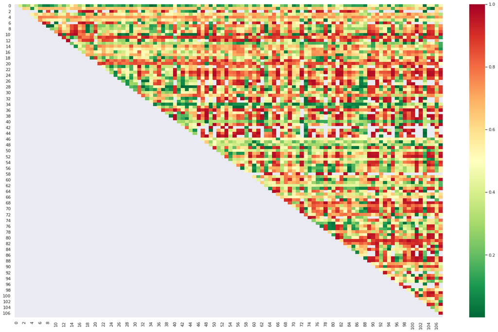

```python
fig = plt.subplots(figsize=(25,15))
m = [0,0.2,0.4,0.6,0.8,1]
sns.heatmap(pvalue_matrix,cmap='RdYlGn_r',mask = (pvalue_matrix >= 0.98))
plt.show()
```

3.3) Resultados Combinados

```python
ativos_LS=list(set(pairs_coint_1)&set(pairs_coint_2))
display(ativos_LS[:10])
len(ativos_LS)
```

```
[('EMBR3', 'GGBR4'),
 ('PCAR4', 'TUPY3'),
 ('BBSE3', 'CSAN3'),
 ('DTEX3', 'ITSA4'),
 ('CPLE3', 'NATU3'),
 ('BRSR6', 'EGIE3'),
 ('BBAS3', 'LINX3'),
 ('EGIE3', 'LINX3'),
 ('BBDC4', 'LINX3'),
 ('IGTA3', 'VIVT4')]
```

```
29
```

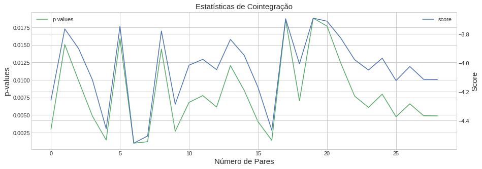

```python
def cointegrated_pairs(data,lista):
    res=[]
    for pair in lista:
        S1 = data[pair[0]]
        S2 = data[pair[1]]
        result = coint(S1, S2)
        res.append([result[0],result[1]])
    return res

score_pvalues=pd.DataFrame(cointegrated_pairs(output,ativos_LS))
fig = plt.subplots(figsize=(15,5))
plt.style.use('seaborn-whitegrid')

ax1 = plt.subplot(111)
ax1.plot(score_pvalues[1],c='g',label='p-values')
ax1.set_ylabel('p-values',fontsize=15)
ax1.set_xlabel("Número de Pares",fontsize=15)
ax1.set_title("Estatísticas de Cointegração",fontsize=15)
ax12 = ax1.twinx()
ax12.plot(score_pvalues[0],label='score')
ax12.set_ylabel("Score",fontsize=15)
ax1.legend(loc='upper left')
ax12.legend(loc='upper right')
```

```python
from scipy.stats.stats import pearsonr
ip=[]
for par in ativos_LS:
    S1 = output[par[0]]
    S2 = output[par[1]]
    ip.append([pearsonr(S1,S2)[0],par])
```

```python
pd.DataFrame(ip).sort_values(by=0, ascending=False)[:10]
```

|  | 0 | 1 |
| --- | --- | --- |
| 22 | 0.979358 | (BBAS3, BBDC4) |
| 18 | 0.972011 | (CPLE3, DIRR3) |
| 25 | 0.968335 | (BBAS3, BRSR6) |
| 4 | 0.967046 | (CPLE3, NATU3) |
| 14 | 0.966368 | (ALPA4, EZTC3) |
| 23 | 0.956707 | (DIRR3, NATU3) |
| 12 | 0.953985 | (B3SA3, NATU3) |
| 15 | 0.942501 | (CSMG3, EGIE3) |
| 3 | 0.937782 | (DTEX3, ITSA4) |
| 21 | 0.936258 | (ENEV3, TOTS3) |

```python
ativos_LS=(pd.DataFrame(ip).sort_values(by=0, ascending=False)[1].values)
ativos_LS
```

```
array([('BBAS3', 'BBDC4'), ('CPLE3', 'DIRR3'), ('BBAS3', 'BRSR6'),
       ('CPLE3', 'NATU3'), ('ALPA4', 'EZTC3'), ('DIRR3', 'NATU3'),
       ('B3SA3', 'NATU3'), ('CSMG3', 'EGIE3'), ('DTEX3', 'ITSA4'),
       ('ENEV3', 'TOTS3'), ('BRSR6', 'EGIE3'), ('EGIE3', 'LINX3'),
       ('CYRE3', 'NATU3'), ('DTEX3', 'ITUB4'), ('DTEX3', 'ITUB3'),
       ('IGTA3', 'VIVT4'), ('BBDC4', 'LINX3'), ('MYPK3', 'TIMP3'),
       ('BBAS3', 'LINX3'), ('MRVE3', 'SBSP3'), ('CSMG3', 'LINX3'),
       ('BRSR6', 'LINX3'), ('BBSE3', 'VIVT4'), ('GOLL4', 'PRIO3'),
       ('PCAR4', 'TUPY3'), ('BBSE3', 'CSAN3'), ('MEAL3', 'VVAR3'),
       ('ABCB4', 'VIVT4'), ('EMBR3', 'GGBR4')], dtype=object)
```

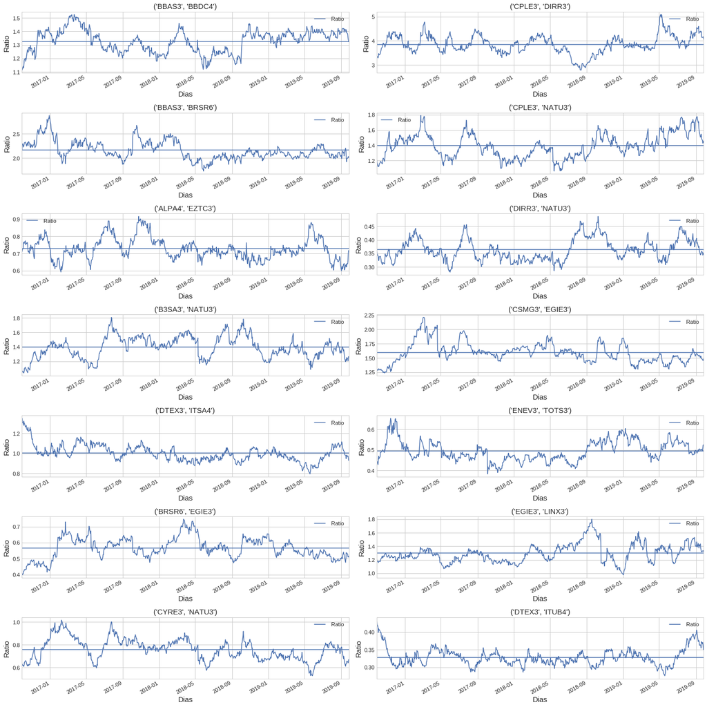

```python
fig = plt.subplots(figsize=(20,20))
plt.style.use('seaborn-whitegrid')

for i in range(0,14):
 #   print(i)
    ax1 = plt.subplot(7,2,i+1)
    S1 = output[ativos_LS[i][0]]
    S2 = output[ativos_LS[i][1]]
 #   score, pvalue, _ = coint(S1, S2)
 #   print(pvalue)
    ratios = S1 / S2
    ratios.plot()
    plt.axhline(ratios.mean())
    plt.legend([' Ratio'])
 #   plt.show()

    plt.ylabel('Ratio',fontsize=15)
    plt.xlabel('Dias',fontsize=15)
    plt.title(ativos_LS[i],fontsize=15)
plt.tight_layout()
```

## 4) Representação Gráfica de Operações Long & Short

Nas operações L&S não interessa se o mercados está em tendência ou lateral. No caso, a abordagem é uma arbitragem entre papéis buscando performance relativa entre as pontas comprada e vendida. No presente estudo foi adotada as bandas de Bollinger, para percepção da distorção dos pares cointegrados, aplicadas diretamente no $Ratio=Preço_A/Preço_B$ que corresponde, simplesmente, à razão dos preços dos dois ativos.

Portanto, o $Ratio$ tende a distorcer para a banda superior se o $Preço_A$ subir relativamente mais que o $Preço_B$, já para a banda inferior no caso contrário. Logo, assumindo que os pares são cointegrados é esperada que a distorção seja eliminada com o tempo, com o retorno do $Ratio$ à média, implicando operacionalmente: 1) o $Ratio$ atingindo a banda de Bolliger inferior uma posição comprada em $Preço_A$ e vendida em $Preço_B$ e 2) o contrário ao atingir a banda superior.

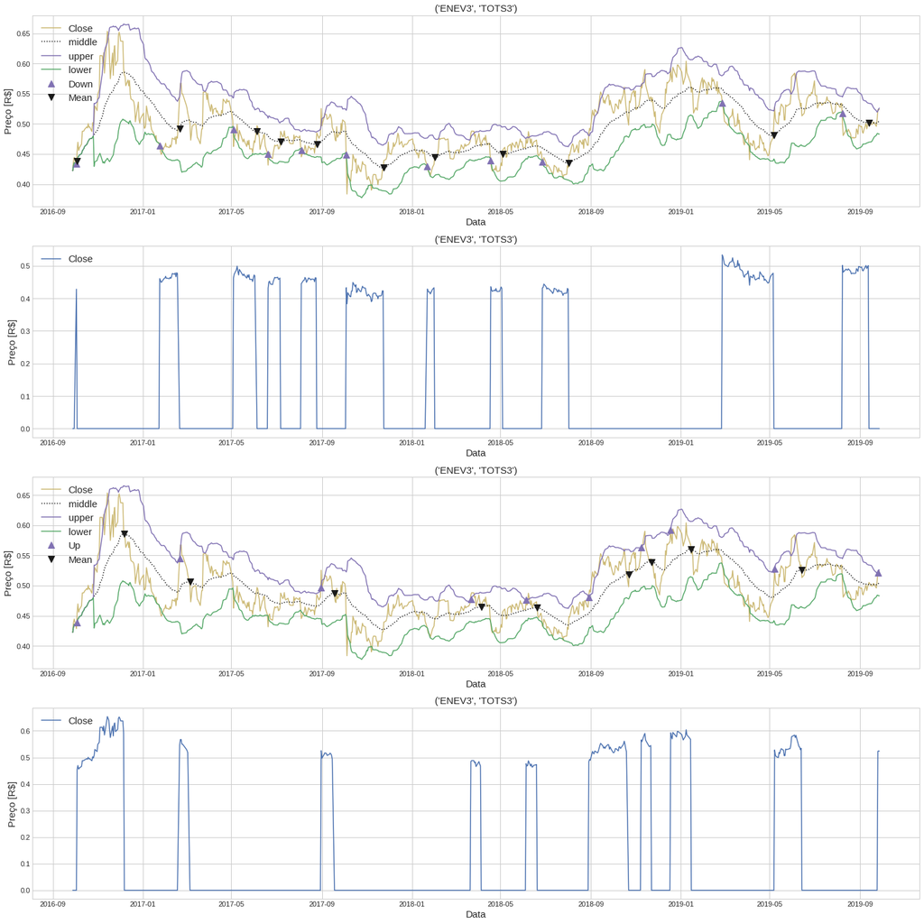

```python
par=9
LS = pd.DataFrame(index=df.index)
LS['Ratio']=output[ativos_LS[par][0]].values/output[ativos_LS[par][1]].values
LS['Ativo_up']=output[ativos_LS[par][0]].values
LS['Ativo_down']=output[ativos_LS[par][1]].values
LS.reset_index(inplace=True)
bollinger_bands(LS,close_col='Ratio')

LS=LS.set_index('Date')


LS['signal_down']=0
signal_down=np.zeros(len(LS['signal_down']))
down=0
LS['signal_up']=0
signal_up=np.zeros(len(LS['signal_up']))
up=0

for day in range(1,len(LS)):

#Operações Compradas
    cond1_down_start=LS['Ratio'].iloc[day-1] > LS['bol_bands_lower'].iloc[day-1]
    cond2_down_start=LS['Ratio'].iloc[day] < LS['bol_bands_lower'].iloc[day]
    cond1_down_end=LS['Ratio'].iloc[day-1] < LS['bol_bands_middle'].iloc[day-1]
    cond2_down_end=LS['Ratio'].iloc[day] > LS['bol_bands_middle'].iloc[day]

    if cond1_down_start & cond2_down_start:
        down = 1
    if (down == True) & cond1_down_end & cond2_down_end:
        down = 0
    signal_down[day]=down

#Operações vendidas
    cond1_up_start=LS['Ratio'].iloc[day-1] < LS['bol_bands_upper'].iloc[day-1]
    cond2_up_start=LS['Ratio'].iloc[day] > LS['bol_bands_upper'].iloc[day]
    cond1_up_end=LS['Ratio'].iloc[day-1] > LS['bol_bands_middle'].iloc[day-1]
    cond2_up_end=LS['Ratio'].iloc[day] < LS['bol_bands_middle'].iloc[day]

    if cond1_up_start & cond2_up_start:
        up = 1
    if (up == True) & cond1_up_end & cond2_up_end:
        up = 0
    signal_up[day]=up


LS['signal_down']=signal_down
LS['signal_up']=signal_up
#condition2=trades['Close'] < trades['bol_bands_lower']

#trades['signal'] = np.where(, 1.0, 0.0)

#trades
# Posição dos trades
LS['positions_down'] = LS['signal_down'].diff()
LS['positions_up'] = LS['signal_up'].diff()

fig = plt.subplots(figsize=(20,20))
plt.style.use('seaborn-whitegrid')

ax1 = plt.subplot(411)
ax1.plot( LS.Ratio, 'y', label = 'Close')
ax1.plot( LS.bol_bands_middle, 'k:', label = 'middle')
ax1.plot( LS.bol_bands_upper, 'm', label = 'upper')
ax1.plot( LS.bol_bands_lower, 'g', label = 'lower')

ax1.plot(LS.loc[LS.positions_down == 1.0].index,
         LS.bol_bands_lower[LS.positions_down == 1.0],
         '^', markersize=10, color='m',label='Down')
ax1.plot(LS.loc[LS.positions_down == -1.0].index,
         LS.bol_bands_middle[LS.positions_down == -1.0],
         'v', markersize=10, color='k',label='Mean')

ax1.set_ylabel("Preço [R$]",fontsize=15)
ax1.set_xlabel("Data",fontsize=15)
ax1.set_title(ativos_LS[par],fontsize=15)
ax1.legend(loc='upper left',fontsize=15)

LS['Ratio_recorte_down']=LS['Ratio']*LS['signal_down']

#trades['Close_recorte'][trades['Close_recorte']==0]=16

ax3 = plt.subplot(412)
ax3.plot(LS['Ratio_recorte_down'], label='Close')
ax3.set_ylabel("Preço [R$]",fontsize=15)
ax3.set_xlabel("Data",fontsize=15)
ax3.set_title(ativos_LS[par],fontsize=15)
ax3.legend(loc='upper left',fontsize=15)


ax2 = plt.subplot(413)
ax2.plot( LS.Ratio, 'y', label = 'Close')
ax2.plot( LS.bol_bands_middle, 'k:', label = 'middle')
ax2.plot( LS.bol_bands_upper, 'm', label = 'upper')
ax2.plot( LS.bol_bands_lower, 'g', label = 'lower')

ax2.plot(LS.loc[LS.positions_up == 1.0].index,
         LS.bol_bands_upper[LS.positions_up == 1.0],
         '^', markersize=10, color='m',label='Up')
ax2.plot(LS.loc[LS.positions_up == -1.0].index,
         LS.bol_bands_middle[LS.positions_up == -1.0],
         'v', markersize=10, color='k',label='Mean')

ax2.set_ylabel("Preço [R$]",fontsize=15)
ax2.set_xlabel("Data",fontsize=15)
ax2.set_title(ativos_LS[par],fontsize=15)
ax2.legend(loc='upper left',fontsize=15)

LS['Ratio_recorte_up']=LS['Ratio']*LS['signal_up']

#trades['Close_recorte'][trades['Close_recorte']==0]=16

ax3 = plt.subplot(414)
ax3.plot(LS['Ratio_recorte_up'], label='Close')
ax3.set_ylabel("Preço [R$]",fontsize=15)
ax3.set_xlabel("Data",fontsize=15)
ax3.set_title(ativos_LS[par],fontsize=15)
ax3.legend(loc='upper left',fontsize=15)
plt.tight_layout()
```

## 5) Dias/Periodos de Posição Long & Short Down e Up

```python
days_down_end=LS['Ratio'][LS['positions_down']==-1].index[1:]
days_down_start=LS['Ratio'][LS['positions_down']==1].index[1:]
if len(days_down_start)>len(days_down_end):
    days_down_start=days_down_start[:len(days_down_end)]
distance_down=days_down_end-days_down_start
print('down')
print(days_down_start)
print(distance_down)

days_up_end=LS['Ratio'][LS['positions_up']==-1].index[1:]
days_up_start=LS['Ratio'][LS['positions_up']==1].index[1:]
if len(days_up_start)>len(days_up_end):
    days_up_start=days_up_start[:len(days_up_end)]
distance_up=days_up_end-days_up_start
print('up')
print(days_up_start)
print(distance_up)
```

```
down
DatetimeIndex(['2017-01-24', '2017-05-04', '2017-06-20', '2017-08-04',
               '2017-10-04', '2018-01-22', '2018-04-18', '2018-06-27',
               '2019-02-26', '2019-08-08'],
              dtype='datetime64[ns]', name='Date', freq=None)
TimedeltaIndex(['27 days', '32 days', '17 days', '21 days', '51 days',
                '10 days', '16 days', '36 days', '70 days', '36 days'],
               dtype='timedelta64[ns]', name='Date', freq=None)
up
DatetimeIndex(['2017-02-20', '2017-08-31', '2018-03-22', '2018-06-05',
               '2018-08-29', '2018-11-08', '2018-12-18', '2019-05-08'],
              dtype='datetime64[ns]', name='Date', freq=None)
TimedeltaIndex(['14 days', '18 days', '14 days', '15 days', '54 days',
                '14 days', '28 days', '37 days'],
               dtype='timedelta64[ns]', name='Date', freq=None)
```

## 6) Resultados Operações Down

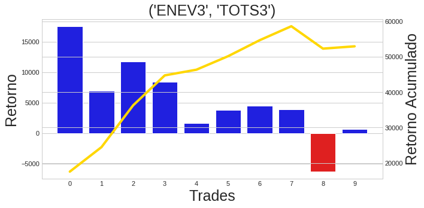

```python
Capital=100000
Result_down = pd.DataFrame(index=days_down_start)
N_Açoes_up=[]
N_Açoes_down=[]
preco_up_start=[]
preco_down_start=[]
Capital_Comprado_start=[]
Capital_Vendido_start=[]
Capital_Comprado_end=[]
Capital_Vendido_end=[]
Retorno_Comprado=[]
Retorno_Vendido=[]
Retorno_Total=[]

for (day,distance) in zip(days_down_start,distance_down):
   # print(day,distance)
    ativo_down_end=LS['Ativo_down'][LS['Ativo_down'].index==(day+distance)].values[0]
    ativo_down_start=LS['Ativo_down'][LS['Ativo_down'].index==(day)].values[0]
    ativo_up_end=LS['Ativo_up'][LS['Ativo_up'].index==(day+distance)].values[0]
    ativo_up_start=LS['Ativo_up'][LS['Ativo_up'].index==(day)].values[0]
    Açoes_up=int((Capital/ativo_up_start)-(Capital/ativo_up_start) % 100)
    Açoes_down=int((Capital/ativo_down_start)-(Capital/ativo_down_start) % 100)
    N_Açoes_up.append(Açoes_up)
    N_Açoes_down.append(Açoes_down)
    Capital_Comprado_start.append(Açoes_up*ativo_up_start)
    Capital_Vendido_start.append(Açoes_down*ativo_down_start)
    Capital_Comprado_end.append(Açoes_up*ativo_up_end)
    Capital_Vendido_end.append(Açoes_down*ativo_down_end)
    preco_up_start.append(ativo_up_start)
    preco_down_start.append(ativo_down_start)

Result_down['N_Açoes_up'] =N_Açoes_up
Result_down['preco_up_start'] =preco_up_start
Result_down['N_Açoes_down'] =N_Açoes_down
Result_down['preco_down_start'] =preco_down_start
Result_down['Capital_Comprado_start']=Capital_Comprado_start
Result_down['Capital_Vendido_start']= Capital_Vendido_start
Result_down['Capital_Comprado_end']= Capital_Comprado_end
Result_down['Capital_Vendido_end']= Capital_Vendido_end
Result_down['Retorno_Comprado']= Result_down['Capital_Comprado_end']-Result_down['Capital_Comprado_start']
Result_down['Retorno_Comprado']= (Result_down['Capital_Comprado_end']-Result_down['Capital_Comprado_start'])#/Result_down['Capital_Comprado_end']
Result_down['Retorno_Vendido']= - (Result_down['Capital_Vendido_end']-Result_down['Capital_Vendido_start'])#/Result_down['Capital_Vendido_end']
Result_down['Retorno_Total']=Result_down['Retorno_Comprado']+Result_down['Retorno_Vendido']

fig = plt.subplots(figsize=(10,5))
plt.style.use('seaborn-whitegrid')
ax1 = plt.subplot(111)
values = np.array(Result_down['Retorno_Total'])
idx = np.array(list(range(len(values))))
clrs = ['red' if (x < 0) else 'blue' for x in values]
sns.barplot(x=idx, y=values, palette=clrs)
plt.ylabel('Retorno',fontsize=25)
plt.xlabel('Trades',fontsize=25)
ax12 = ax1.twinx()
ax12.plot(np.cumsum(values),'gold',linewidth=4)
plt.ylabel('Retorno Acumulado',fontsize=25)
plt.xlabel('Trades',fontsize=25)
plt.title(ativos_LS[par],fontsize=25)
plt.tight_layout()
```

## 7) Resultados Operações Up

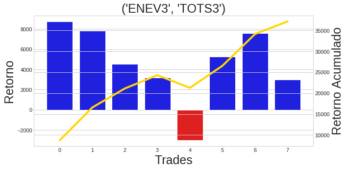

```python
Capital=100000
Result_up = pd.DataFrame(index=days_up_start)
N_Açoes_up=[]
N_Açoes_down=[]
preco_up_start=[]
preco_down_start=[]
Capital_Comprado_start=[]
Capital_Vendido_start=[]
Capital_Comprado_end=[]
Capital_Vendido_end=[]
Retorno_Comprado=[]
Retorno_Vendido=[]
Retorno_Total=[]

for (day,distance) in zip(days_up_start,distance_up):
   # print(day,distance)
    ativo_down_end=LS['Ativo_down'][LS['Ativo_down'].index==(day+distance)].values[0]
    ativo_down_start=LS['Ativo_down'][LS['Ativo_down'].index==(day)].values[0]
    ativo_up_end=LS['Ativo_up'][LS['Ativo_up'].index==(day+distance)].values[0]
    ativo_up_start=LS['Ativo_up'][LS['Ativo_up'].index==(day)].values[0]
    Açoes_up=int((Capital/ativo_up_start)-(Capital/ativo_up_start) % 100)
    Açoes_down=int((Capital/ativo_down_start)-(Capital/ativo_down_start) % 100)
    N_Açoes_up.append(Açoes_up)
    N_Açoes_down.append(Açoes_down)
    Capital_Vendido_start.append(Açoes_up*ativo_up_start)
    Capital_Comprado_start.append(Açoes_down*ativo_down_start)
    Capital_Vendido_end.append(Açoes_up*ativo_up_end)
    Capital_Comprado_end.append(Açoes_down*ativo_down_end)
    preco_up_start.append(ativo_up_start)
    preco_down_start.append(ativo_down_start)

Result_up['N_Açoes_up'] =N_Açoes_up
Result_up['preco_up_start'] =preco_up_start
Result_up['N_Açoes_down'] =N_Açoes_down
Result_up['preco_down_start'] =preco_down_start
Result_up['Capital_Comprado_start']=Capital_Comprado_start
Result_up['Capital_Vendido_start']= Capital_Vendido_start
Result_up['Capital_Comprado_end']= Capital_Comprado_end
Result_up['Capital_Vendido_end']= Capital_Vendido_end
Result_up['Retorno_Comprado']= Result_up['Capital_Comprado_end']-Result_up['Capital_Comprado_start']
Result_up['Retorno_Comprado']= (Result_up['Capital_Comprado_end']-Result_up['Capital_Comprado_start'])#/Result_down['Capital_Comprado_end']
Result_up['Retorno_Vendido']= - (Result_up['Capital_Vendido_end']-Result_up['Capital_Vendido_start'])#/Result_down['Capital_Vendido_end']
Result_up['Retorno_Total']=Result_up['Retorno_Comprado']+Result_up['Retorno_Vendido']

fig = plt.subplots(figsize=(10,5))
plt.style.use('seaborn-whitegrid')
ax1 = plt.subplot(111)
values = np.array(Result_up['Retorno_Total'])
idx = np.array(list(range(len(values))))
clrs = ['red' if (x < 0) else 'blue' for x in values]
sns.barplot(x=idx, y=values, palette=clrs)
plt.ylabel('Retorno',fontsize=25)
plt.xlabel('Trades',fontsize=25)
ax12 = ax1.twinx()
ax12.plot(np.cumsum(values),'gold',linewidth=4)
plt.ylabel('Retorno Acumulado',fontsize=25)
plt.xlabel('Trades',fontsize=25)
plt.title(ativos_LS[par],fontsize=25)
plt.tight_layout()
```

## 8) Resultados Consolidados Down Up

```
0
1
2
3
4
5
6
7
8
9
```

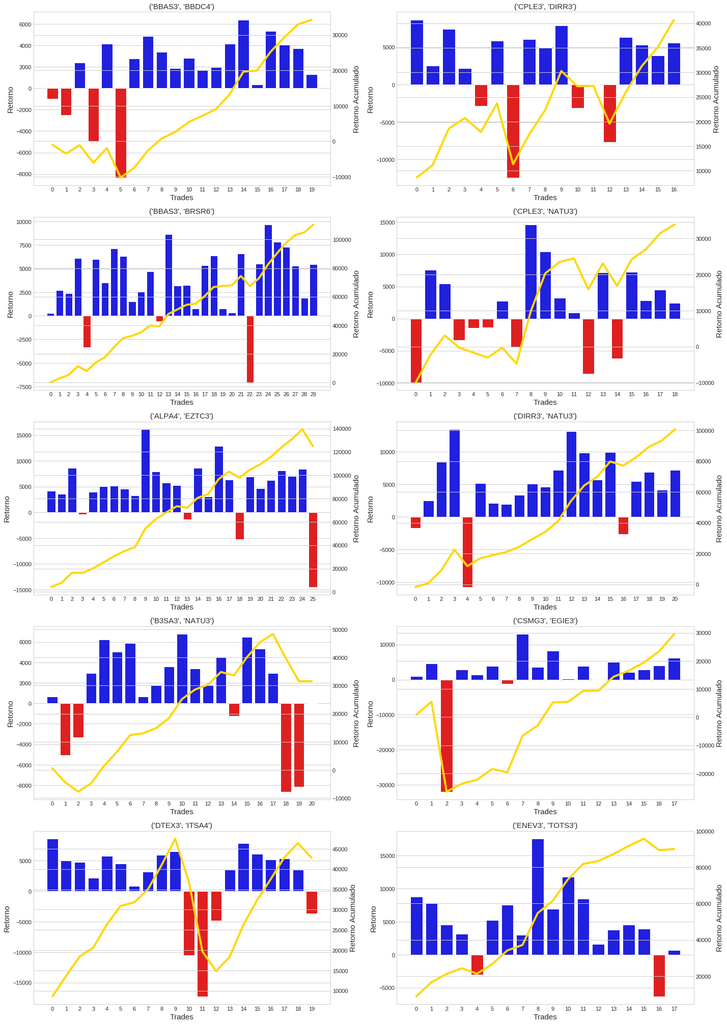

```python
Result_up['tipo']='up'
Result_down['tipo']='down'
Result = pd.concat([Result_up, Result_down], axis=0)
Result[Result.columns[-4:]].sort_index()
if par==0:
    Result_All=[]
Result_All.append(Result['Retorno_Total'])
len(Result_All)
fig = plt.subplots(figsize=(20,len(Result_All)*5))
plt.style.use('seaborn-whitegrid')

for i in range(0,par+1):
    print(i)
    ax1 = plt.subplot(par,2,i+1)
    values = np.array(Result_All[i])
    idx = np.array(list(range(len(values))))
    clrs = ['red' if (x < 0) else 'blue' for x in values]

    sns.barplot(ax=ax1,x=idx, y=values, palette=clrs)

    plt.ylabel('Retorno',fontsize=15)
    plt.xlabel('Trades',fontsize=15)
    ax12 = ax1.twinx()

    ax12.plot(np.cumsum(values),'gold',linewidth=4)
    plt.ylabel('Retorno Acumulado',fontsize=15)
    plt.xlabel('Trades',fontsize=15)
    plt.title(ativos_LS[i],fontsize=15)
    plt.tight_layout()
```

```python
def result(values):
    x=values
    lr=np.mean(x)/np.std(x)
    gains=[x for x in values if x > 0]
    losses=[x for x in values if x < 0]
    return len(x), lr, len(gains)/len(losses), 100*len(gains)/len(x), np.sum(values)

values=[Result_All[i].values for i in range(len(Result_All))]

print()
print('Resultados Consolidados para as 4 Estratégias:')
print()
for vl,i in zip(values,range(len(values))):
    OP, LR, FL, Gains, Profit=result(vl)
    print('%s: Operações: %.i L/R: %.2f, FL: %.2f, Lucro: %.2f e Taxa de Acertos: %.2f '
          % ((ativos_LS[i]),OP, LR, FL, Profit,Gains ))
```

[output not shown]

Naturalmente, a abordagem apresentada possuí natureza didática e tornar a estratégia operacional exige complementações importantes e estudos adicionais. Assim, citando alguns aspectos relevantes:

- Estabelecimento de Stop Loss, já que observamos que podem ocorrer perdas significativas
- A cointegração indica que teremos retornos à média, porém é importante que as distoções sejam razoáveis e em frequência adequada
- É importante a otimização de paramêntros associado ao indicador de distorção
- Avaliação in-sample e out-of-sample são fundamentais, inclusive com aplicação do WFA (Walk Forward Analisys)
- Uma normalização zscore pode ser adotada e as bandas de Bollinger substituidas por distâncias fixas a partir do zero

É certo que outros aspectos podem ser abordados. Contudo, não deixa de ser interessante que mesmo na sua forma mais primitiva as opeações L&S, apresentadas na presente aula, indicaram vencedoras no tempo

**Fim da Atividade!!!**